# Strikes in Steel Belt US Military Industry, 1966

Alex Trahan

2024-10-10

What effect did the Vietnam War have on labor relations within the US Military Industrial Complex?

From 1962 to 1965, the Labor Relations staff attached to US Army Mobility Command (MOCOM), based at the Detroit Tank Arsenal in Warren, Michigan, kept scattered, mostly handwritten records of the few dozen work stoppages that military contractors were required to report. Then, in 1966, strike activity inside military contractors plants exploded, producing enough reports - now standardized through a special form label DD-1507: Work Stoppage Report - to fill an entire US National Archives FRC box.

These DTA records provide only a partial scan of the whole body of military industry in the year 1966. DTA Labor Relations staff reporting on work stoppages focused almost exclusively on contracts overseen by the staff’s parent agency, MOCOM. We rarely glimpse occurrences of labor unrest affecting contracts overseen by other Army commands, much less other branches of the US military. That said, MOCOM oversaw contracts for a number of big-ticket conventional hardware, like the M60 tank, the M109 self-propelled howitzer, and M110 armored personnel carrier, as well as many smaller but still important items, like trucks, shop vans, and the small horse-power engines used as generators to run AC in tropical Southeast Asia. This scan may be incomplete, but it captures vital organs of military industry, and its gaps merely point beyond itself to an even wider discrepancy between BLS data and the actual reality of shopfloor conflicts brought to boil by the intensification of US military involvement in the Vietnam War. The total number of strikes, strikers, and production days lost likely to be much higher than what is recorded in this document.

The stakes of this discrepancy between BLS data and DTA records are much deeper than simple accurate account; it matters for our understanding of how the United States’ long, brutal, and industrially intense war in Southeast Asia shaped political-economic and social relations on its own soil. We know that the United States turned Southeast Asia into the most bombed region on the planet, dropping more bombs at a faster rate, than it used across all theatres of the Second World War. But we do not yet know enough about *how* all this materiel was made, *who* made it, and *what effects* its production had on social reality during a disavowed war with a disavowed home front.

*Nota Bene:* The purpose of this document is to serve as a heuristic for guiding research questions and in-depth qualitative investigation. It is neither a formal preview of a finished research project nor even a prospectus for a regimented quantitative analysis.

# BLS Data for 1966

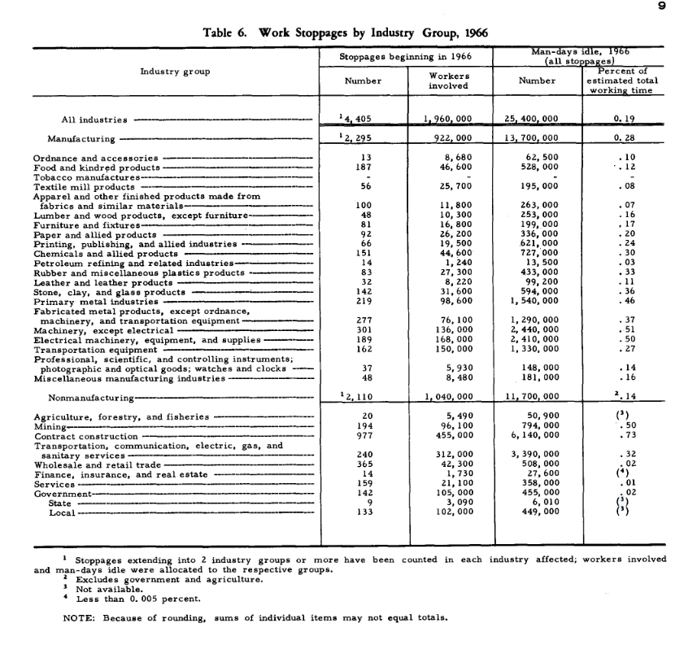

BLS Work Stoppages Analyis, 1966 (p. 9)

# Summary Statistics DTA Labor Relations Records, 1966

Strike events by type

| Type | count |
| --- | --- |
| authorized strike | 75 |
| potential strike (averted) | 7 |
| wildcat strike | 21 |

Summary stats for Actual Strikes (Authorized + Wildcat)

| Total Strikes | 96 |
| --- | --- |
| Total Strikers | 49,052 |
| Worker-Days Lost | 789,992 |

Workers on Strike

| Minimum Strikers | 3 |
| --- | --- |
| Maximum Strikers | 5200 |
| Mean Strikers | 831 |
| Median Strikers | 320 |
| Standard Deviation | 1108 |

Strike Length

| Mean Strike Length | 26 |
| --- | --- |
| Median Length | 13 |
| Minimum Strike Length | 1 |
| Maximum Strike Length | 183 |

Work-Days Lost

| Minimum Worker-Days Lost | 3 |
| --- | --- |
| Maximum Worker-Days Lost | 78000 |
| Mean Worker-Days Lost | 14107 |
| Median Worker-Days Lost | 8050 |
| Average Percentage of Worker-Time Lost | 7 |

Estimated Percentage of Production Time Lost by Military Contractors in Data

| 6.795091 |
| --- |

How the above value is calculated: ( (sum of days lost to all strikes) / [(sum of all contractors) * 365)] )*100. This slightly over estimates percentage of productivity days lost because it double counts a small number of factories that featured multiple strikes and assumes that every factory operated 365 days a year.

# Strikes and Strikers Over Time

Total Strikes and Total Strikers by Month, 1966

| Metric | Jan | Feb | Mar | Apr | May | Jun | Jul | Aug | Sep | Oct | Nov | Dec |
| --- | --- | --- | --- | --- | --- | --- | --- | --- | --- | --- | --- | --- |
| Total Strikes | 6 | 9 | 10 | 10 | 6 | 12 | 10 | 7 | 8 | 8 | 7 | 3 |
| Total Strikers | 7433 | 8020 | 6574 | 5732 | 3089 | 1468 | 1433 | 623 | 2360 | 2452 | 9808 | 60 |

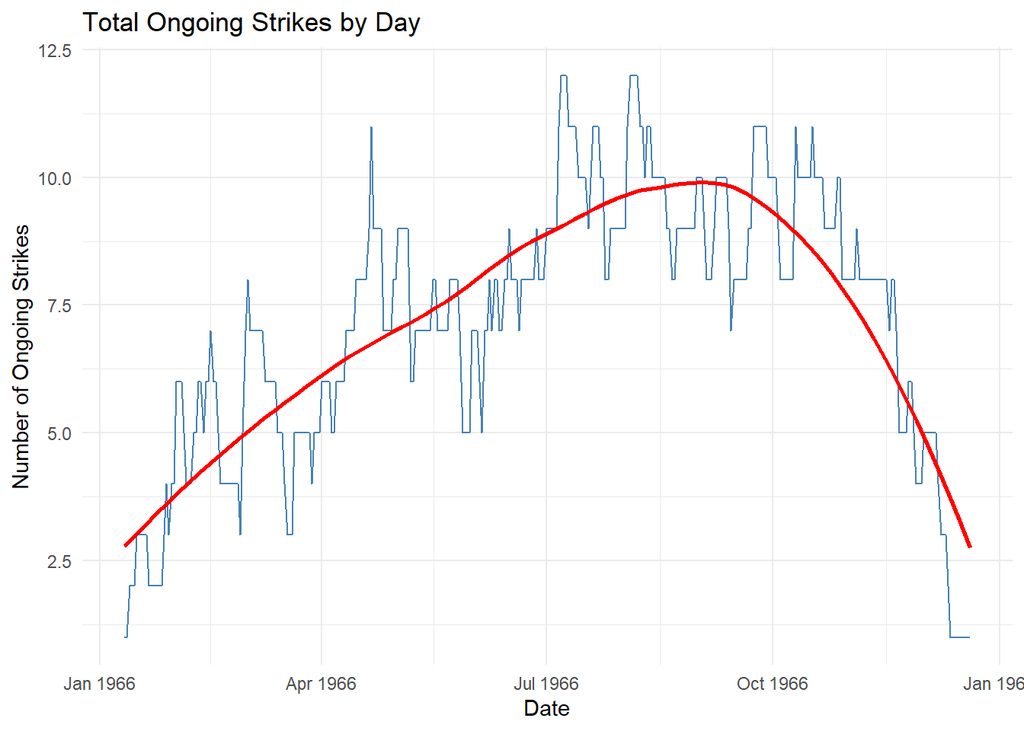

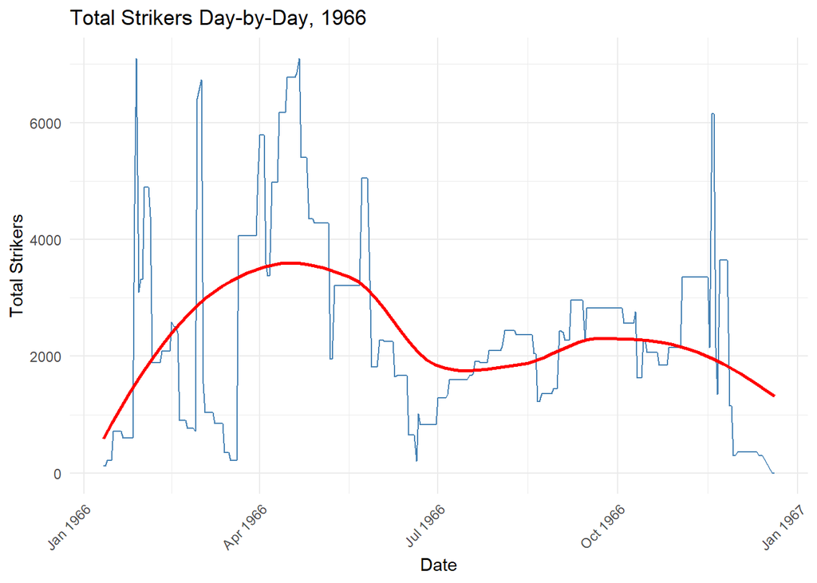

# Geography of Military Industry Strikes in DTA Records, 1966

#### Two of the following maps have interactive features when viewed as stand-alone HTML documents. Click on a marker to reveal specific information about a strike. Please note, these interactive functions are not available when the maps are viewed as part of the larger document.

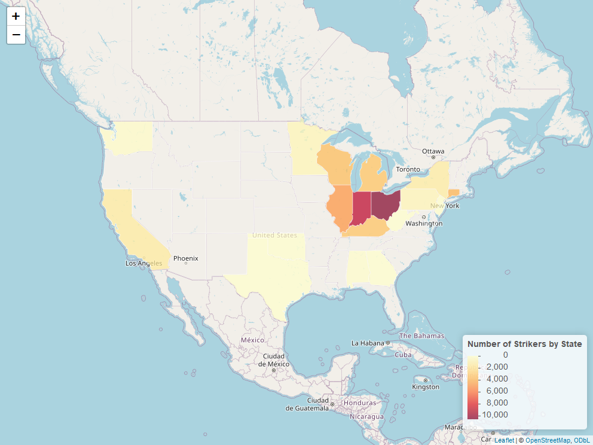

States by frequency

| state | frequency |
| --- | --- |
| Ohio | 26 |
| Michigan | 17 |
| Indiana | 9 |
| Wisconsin | 8 |
| Illinois | 7 |
| California | 6 |
| Pennsylvania | 3 |
| Alabama | 2 |
| Connecticut | 2 |
| Kentucky | 2 |
| Minnesota | 2 |
| Oklahoma | 2 |
| Georgia | 1 |
| Massachusetts | 1 |
| Michicagn | 1 |
| Texas | 1 |
| Washington | 1 |

[figure not shown]

[figure not shown]

# What cities are in the data?

Top 5 Cities by Frequency of Strikes

| City | Number of Strikes | Total Strikers |
| --- | --- | --- |
| Detroit, Michigan | 4 | 350 |
| Lima, Ohio | 4 | 2029 |
| Milwaukee, Wisconsin | 4 | 1700 |
| Dayton, Ohio | 3 | 600 |
| Akron, Ohio | 2 | 1600 |

| City | Number of Strikes | Total Strikers |
| --- | --- | --- |
| Detroit, Michigan | 4 | 350 |
| Lima, Ohio | 4 | 2029 |
| Milwaukee, Wisconsin | 4 | 1700 |
| Dayton, Ohio | 3 | 600 |
| Akron, Ohio | 2 | 1600 |

Frequency Distribution of Number of Strikes

| Number of Strikes | Frequency |
| --- | --- |
| 4 | 3 |
| 3 | 1 |
| 2 | 6 |
| 1 | 68 |

All Cities, Arranged by Number of Strikes

| City | Number of Strikes | Total Strikers |
| --- | --- | --- |
| Detroit, Michigan | 4 | 350 |
| Lima, Ohio | 4 | 2029 |
| Milwaukee, Wisconsin | 4 | 1700 |
| Dayton, Ohio | 3 | 600 |
| Akron, Ohio | 2 | 1600 |
| Buffalo, New York | 2 | 150 |
| Chicago, Illinois | 2 | 1713 |
| Elyria, Ohio | 2 | 0 |
| Fort Wayne, Indiana | 2 | 1065 |
| San Jose, California | 2 | 1219 |
| Alameda, California | 1 | 3 |
| Anniston, Alabama | 1 | 65 |
| Belioit, Wisconsin | 1 | 1200 |
| Bucyrus, Ohio | 1 | 0 |
| Buffton, Indiana | 1 | 190 |
| California | 1 | 0 |
| Carrollton, Texas | 1 | 0 |
| Charleston, West Virginia | 1 | 0 |
| Cincinnati, Ohio | 1 | 135 |
| Claremont, California | 1 | 100 |
| Cleveland, Ohio | 1 | 0 |
| Coldwater, Michigan | 1 | 217 |
| Columbus, Indiana | 1 | 5200 |
| Columbus, Ohio | 1 | 1350 |
| Delphos, Ohio | 1 | 210 |
| Elba, Alabama | 1 | 0 |
| Elmira, New York | 1 | 0 |
| Erie, Pennsylvania | 1 | 0 |
| Evansville, Indiana | 1 | 500 |
| Fostoria, Ohio | 1 | 0 |
| Fullerton, California | 1 | 0 |
| Galion, Ohio | 1 | 200 |
| Galion, Ohio & Bucyrus, Ohio | 1 | 500 |
| Hayward, California | 1 | 134 |
| Highland, Illinois | 1 | 0 |
| Horseheads, New York | 1 | 1200 |
| Jeannette, Pennsylvania | 1 | 190 |
| Kalamazoo, Michigan | 1 | 1130 |
| Kent, Ohio | 1 | 550 |
| LaPorte, Indiana | 1 | 0 |
| Lansing, Michigan | 1 | 120 |
| Lebanon, Pennsylvania | 1 | 500 |
| Livonia, Michigan | 1 | 22 |
| Long Island, New York | 1 | 30 |
| Louisille, Kentucky | 1 | 3400 |
| Louisville, Kentucky | 1 | 0 |
| Lynn, Massachusetts & Everett, Massachusetts | 1 | 0 |
| Manistee, Michigan | 1 | 320 |
| Marion, Indiana | 1 | 1839 |
| Massillon, Ohio | 1 | 0 |
| Mattoon, Illinois | 1 | 302 |
| Minneapolis, Minnesota | 1 | 675 |
| Musekgon, Michigan | 1 | 0 |
| New Haven, Connecticut | 1 | 0 |
| Newark, Ohio | 1 | 2500 |
| Northlake, Illinois | 1 | 2105 |
| Oak Park, Michigan | 1 | 50 |
| Oshkosh, Wisconsin | 1 | 0 |
| Pontiac, Michigan | 1 | 0 |
| Port Huron, Michigan | 1 | 0 |
| Princeton, Indiana | 1 | 451 |
| Renton, Washington | 1 | 184 |
| Rock Falls, Illinois | 1 | 262 |
| Roseville, Michigan | 1 | 0 |
| South Bend, Indiana | 1 | 0 |
| Springfield, Ohio | 1 | 217 |
| St Marys, Ohio | 1 | 0 |
| St Paul, Minnesota | 1 | 0 |
| Sterling, Michicagn | 1 | 2500 |
| Stratford, Connecticut | 1 | 4000 |
| Toledo, Ohio | 1 | 80 |
| Traverse City, Michigan | 1 | 135 |
| Troy, New York | 1 | 0 |
| Tulsa, Oklahoma | 1 | 0 |
| Van Dalia, Ohio | 1 | 0 |
| Warren, Michigan | 1 | 1100 |
| Wausau, Wisconsin | 1 | 680 |
| Wisconsin Dells, Wisconsin | 1 | 80 |

- Note: A valude of 0 indicates that a strike occurred by DTA labor relations staff did not record the total number of employees involved in a work stoppage

### To Do:

- continue cleaning up data manually
- clean up cities
- clean up state column